# Poly-Z Gate

## Qiskit Representation

### This is the process of a one quibit circuit being built, having an Z-Gate and measurement applied, then ploting the results goes in code

```python
import numpy as np
import qiskit as q
# Importing standard Qiskit libraries
from qiskit import QuantumCircuit, transpile, Aer, IBMQ
from qiskit.tools.jupyter import *
from qiskit.visualization import *
from ibm_quantum_widgets import *

# Loading your IBM Quantum account(s)
provider = IBMQ.load_account()
```

```
ibmqfactory.load_account:WARNING:2021-05-27 15:56:13,805: Credentials are already in use. The existing account in the session will be replaced.
```

# Constructing the circuit

## Makes the quantum circuit "foundation". The first parameter is the number of qubits (quantum bits) the second parameter is the number of cbits (classical bits), this lets us store the information to be read by the simulator

```python
zGateExample = QuantumCircuit(1,1)
```

## Adds an Poly-Z gate to the first qubit (represented by the number zero)

```python
zGateExample.z(0)
```

```
<qiskit.circuit.instructionset.InstructionSet at 0x7f2f1492cc40>
```

## Adds an measurement operator to the first qubit and results stored in the first cbit

```python
zGateExample.measure(0,0)
```

```
<qiskit.circuit.instructionset.InstructionSet at 0x7f2f12839460>
```

## Draws the circuit out for a visual representation

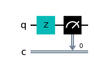

```python
zGateExample.draw()
```

# Choosing the backend and gathering results

## Choosing a backend from the avaible computers with my account. The QASM Simulator is a regular computer doing this as a simulation to give an idea of what probabilities of the outcomes are for the circuit

```python
backend = Aer.get_backend("qasm_simulator")
```

```python
job = q.execute(zGateExample, backend)
```

## Gathers the results from the execution done in the previous statement

```python
results = job.result()
```

## Gathers the counts of how many times 1 or 0 was the result

```python
counts = results.get_counts()
```

# Results

## Plots the counts on a histogram shown below

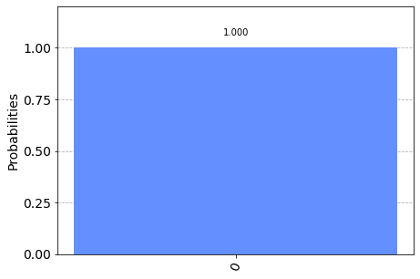

```python
plot_histogram(counts)
```